| JÉZÉGOU | Pierre-Yves |
| --- | --- |
| LE BER | NICOLAS |

# Machine Learning Programming Exercise 6: Supervised classification

## Objectifs

Nous allons dans ce TP classer automatiquement des patchs extraits d'images sonar (cf. figure ci-dessous) en types de fond marin (roches, sables, vases, rides de sable verticales et à 45°, [Posidonie](https://fr.wikipedia.org/wiki/Posidonia_oceanica)).

Quelques exemples de patchs d'image sonar de fond marin:

[figure not shown]

L'objectif est d'écrire des scripts permettant de mettre en \oe uvre un système basé sur différentes approches supervisées de machine learning. Ces scripts devront ainsi suivre la chaîne générale décrite en cours (à l'exception de la phase de captation; cf. figure ci-dessous ) :

- prétraitements
- extraction des descripteurs
- apprentissage d'un modèle de classement
- classement des pixels
- évaluation du classifieur appris

[figure not shown]

Le TP est globalement organisé de la manière suivante

- **Données**
  1. tout d'abord apprendre les modèles de classement (classifieurs) sur les données brutes (descripteurs=features=valeurs des pixels)
  2. puis dans un second temps sur des descripteurs extraits à partir d'un algorithme appelé [scattering operator](https://www.di.ens.fr/data/scattering) (le fonctionnement exact n'est pas au programme mais il s'apparente à une banque de filtres mise en cascade).
- **Prétraitements** Aucun prétraitement ne sera réalisé.
- **Ensembles de données**
  1. Les ensembles de données seront composés de 1/3 de la base totale d'images.
  2. Dans un second temps, nous procéderons par [validation croisée](https://scikit-learn.org/stable/modules/cross_validation.html) car la base d'images est de taille réduite.
- **Algorithmes** Concernant les algorithmes supervisés de machine learning, l'objectif est d'utiliser les deux algorithmes de regression logistique et de réseaux de neurones que vous avez développés aux TP précédents et de découvrir le package python [scikit-learn](http://scikit-learn.org/stable/user_guide.html) qui vous permettra d'utiliser les algorithmes de [régression logistique](https://scikit-learn.org/stable/modules/linear_model.html#logistic-regression), [réseaux de neurones](https://scikit-learn.org/stable/modules/neural_networks_supervised.html), [random forests](https://scikit-learn.org/stable/modules/ensemble.html#forest) et [svm](https://scikit-learn.org/stable/modules/svm.html#svm-classification).
- Pour commencer avec cette séance, vous aurez besoin de **télécharger** le *starter code* disponible sur le lien Moodle du cours.

**Dans cet exercice, il vous est demandé de fournir un rapport regroupant les réponses aux questions, vos analyses et vos codes. Ce rapport pourra prendre la forme d'un pdf ou d'un jupyter notebook. Il est de plus conseillé de faire tourner les codes sur google colab si votre machine manque de puissance (dans ce cas un jupyter notebook est nécessaire).**

## Fichiers inclus dans le starter code pour cette séance

- **pythonTools.py** - fonctions utiles pour l'affichage, le chargement des données et l'évaluation des performances
- **usefulCmds.py** - quelques commandes pour faciliter l'import des patchs
- **dataSet** - répertoire avec les images et les labels correspondants
- **dataSet\imdb_200x200_SmallSonarTex_db_6classes_scatValOnly.mat** - fichier matlab contenant les descripteurs extraits des images par le scattering operator

# Part 0: intro

## 0.1 imports

*Your commented code below*

```python
# System libraries
import sys
import os

# Data manipulation and visualisation libraries
from numpy.random import rand
import scipy as sp
import numpy as np
import pandas as pd
import matplotlib.pyplot as plt

import seaborn as sns
from PIL import Image

import scipy.ndimage as spi


# Libraries to label the data
import skimage.transform
from sklearn import preprocessing
from sklearn.model_selection import train_test_split

from scipy.optimize import fmin_tnc, fmin_cg, fmin_l_bfgs_b
```

## 0.2 Examen des données

Écrire des lignes de code permettant:

- de charger les données comprises dans le fichier *labels.csv*,
- de mettre en matrice les descripteurs de l'ensemble de la base d'images
- d'afficher les images avec la fonction _plot_batch()_ du fichier _pythonTools.py_,

*Your commented code below*

```python
import sys
IN_COLAB = 'google.colab' in sys.modules

if IN_COLAB:
    DATASET_PATH = '/content/drive/MyDrive/Colab Notebooks/dataset/imgs/'
    LABEL_PATH = '/content/drive/MyDrive/Colab Notebooks/dataset/labels/labels.csv'
    os.chdir("/content/drive/MyDrive/Colab Notebooks")
    from pythonTools import *
else:
    IN_COLAB = False
    DATASET_PATH = r'./dataset/imgs/'
    LABEL_PATH = r'./dataset/labels/labels.csv'
    from pythonTools import *

dataset_df = pd.read_csv(LABEL_PATH)
# We add another column to the labels dataset to identify image path
dataset_df['image_path'] = dataset_df.apply(lambda row: (DATASET_PATH + row['id']), axis=1)

#chargement des image sous forme de vecteur de 40000*1
features_value = np.array([plt.imread(img).reshape(40000,) for img in dataset_df['image_path'].values.tolist()])

img_count = features_value.shape[0]
img_shape = (int(np.sqrt(features_value.shape[1])), int(np.sqrt(features_value.shape[1])))
features_count = features_value.shape[1]
num_channels = 1

print("Features informations:\n\tImages count: {}\n\tImages Shape: {}\n\tFeatures Count: {}\n\tColor Channels: {}".format(img_count, img_shape, features_count, num_channels))
```

```
None
Features informations:
	Images count: 360
	Images Shape: (200, 200)
	Features Count: 40000
	Color Channels: 1
```

```
Random images selection from dataset:
```

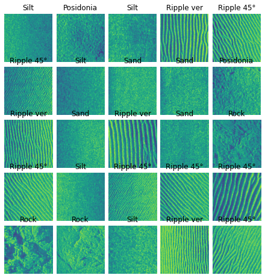

```python
print("Random images selection from dataset:\n")
plot_grid = (5,5)
images_scale = 1
batch_size = plot_grid[0]*plot_grid[1]
images_df = load_batch(dataset_df, batch_size)
plot_batch(images_df, plot_grid[0], plot_grid[1], images_scale*img_shape[0], images_scale*img_shape[1])
```

**Question: Quel est le nombre de données, le nombres de descripteurs**

On a donc 360 image de 200*200 pixel soit 40 000 descripteurs par image

## 0.3 prétraitements des labels

Écrire des lignes de code, un script ou une fonction *preprocessing()* permettant:

- de disposer des labels dans différents [codages](https://scikit-learn.org/stable/modules/preprocessing_targets.html) (noms, indices, one-hot-encoding, etc.)

*Your commented code below*

```python
# Loading Labels
label_names = dataset_df['seafloor']
label_names_unique = label_names.unique()

num_labels = label_names_unique.shape[0]

print("Labels:\n\tNames: {}\n\tCount: {}".format(label_names_unique, num_labels))

# Encoding Labels
#  Label Index
le = preprocessing.LabelEncoder()
le.fit(label_names_unique)
label_indices = le.transform(label_names_unique)

# One Hot Encoding
labels_one_hot = pd.get_dummies(label_names.reset_index(drop=True)).values


y = (le.transform(label_names)).reshape((img_count, 1))

print("Extract from y:\n{}".format(y[55:65]))
```

```
Labels:
	Names: ['Posidonia' 'Ripple 45°' 'Rock' 'Sand' 'Silt' 'Ripple vertical']
	Count: 6
Extract from y:
[[0]
 [0]
 [0]
 [0]
 [0]
 [1]
 [1]
 [1]
 [1]
 [1]]
```

## 0.4 Séparation des données en ensembles

Écrire des lignes de code, un script ou une fonction *preprocessing()* permettant:

- de [normaliser](https://scikit-learn.org/stable/modules/preprocessing.html) les données si besoin
- de [créer deux ensembles](https://scikit-learn.org/stable/modules/generated/sklearn.model_selection.train_test_split.html#sklearn.model_selection.train_test_split) un pour l'apprentissage et un pour le test

*Your commented code below*

```python
X_train, X_test, y_train, y_test = train_test_split(features_value, y, test_size=0.33, random_state=42)
print("Training and testing sets:\n\tX_train: {}\n\ty_train: {}\n\tX_test:  {}\n\ty_test:  {}".format(X_train.shape, y_train.shape,X_test.shape,y_test.shape))

print("\nDatasets representativeness:")
ind, counts = np.unique(le.inverse_transform(y_train), return_counts=True)
train_classes =dict(zip(ind, counts))
print("\tTraining : {}".format(train_classes))

ind, counts = np.unique(le.inverse_transform(y_test), return_counts=True)
test_classes =dict(zip(ind, counts))
print("\tTesting  : {}".format(test_classes))

classes = {}
for key, item in train_classes.items():
    classes[key] = item + test_classes[key]

print("\nFull Dataset classes:\n\t{}".format(classes))
```

```
Training and testing sets:
	X_train: (241, 40000)
	y_train: (241, 1)
	X_test:  (119, 40000)
	y_test:  (119, 1)

Datasets representativeness:
	Training : {'Posidonia': 39, 'Ripple 45°': 36, 'Ripple vertical': 39, 'Rock': 43, 'Sand': 38, 'Silt': 46}
	Testing  : {'Posidonia': 21, 'Ripple 45°': 24, 'Ripple vertical': 21, 'Rock': 17, 'Sand': 22, 'Silt': 14}

Full Dataset classes:
	{'Posidonia': 60, 'Ripple 45°': 60, 'Ripple vertical': 60, 'Rock': 60, 'Sand': 60, 'Silt': 60}
```

**Question: Quel est le nombre de données totales et pour chaque classe, le nombres de descripteurs pour chaque ensemble de données**

*votre réponse ici:*

on retrouve donc 360 images ayant chacune 40 000 descripteur, pour chaque classe on retouve 60 images

# Part 1 approches supervisées sur données brutes

**Question: Y-a-t-il besoin de normaliser les descripteurs? Si oui, que faut-il conserver comme information et pourquoi?**

La normalisaion des descripteurs permet l'optimisation des traitements, le plus important etant de conserver les contrast des images si ce nes même les exacerber afin de facilité les decisions

**Question: Nous allons apprendre les modèles suivants:

- régression logistique régularisée et réseaux de neurones développés dans les tps précédents,
- régression logistique, réseaux de neurones (solver=lbfgs), svm et random forest en utilisant les fonctions du package scikit-learn

Faire la liste des hyper-paramètres (paramètre uniquement lié à l'algorithme d'apprentissage) de chaque algorithme. Comment fixe-t-on leurs valeurs?**

Dans le cas d'une regression logisitque utilisé pour une classification en One vs All, l'Hyperparametre le plus important est $\lambda$ car il definis le degré du polynome utilisé comme frontiere de decision

**Question: Fixez au mieux les valeurs des hyperparamètres, réalisez l'apprentissage des modèles suivants:**

- régression logistique régularisée et réseaux de neurones développés dans les tps précédents,
- régression logistique, réseaux de neurones, svm et random forest en utilisant les fonctions du package scikit-learn </strong>

## Régression Logistique

```python
# SIGMOID
def sigmoid(z):
    return 1 / (1 + np.exp(-z))

print("Testing sigmoid:")
print("simgoid(0)={}".format(sigmoid(0)))
print("simgoid(I\u2083)=\n{}".format(sigmoid(np.array([[1,0,0],[0,1,0],[0,0,1]]))))

# Cost Function
def lrCostFunction(theta, X, y, Lambda):
    # Initialize some useful values
    m,n = X.shape  # number of training examples and parameters
    theta = theta.reshape((n,1))  # due to the use of fmin_tnc
    # =============================================================
    h_theta = sigmoid(X@theta)
    inner = -y*np.log(h_theta) - (1-y)*np.log(1-h_theta)
    inner2 = np.linalg.norm(theta[1:])**2
    J = np.sum(inner)/m + inner2*Lambda/(2*m)
    # =============================================================
    return J

# Gradient
def lrCostGradient(theta, X, y, Lambda):
    # Initialize some useful values
    m,n = X.shape  # number of training examples and parameters
    theta = theta.reshape((n,1))  # due to the use of fmin_tnc
    # =============================================================
    h_theta = sigmoid(X@theta)
    inner = (h_theta-y).T@X
    grad = inner/m
    theta0 = grad[0][0]
    grad = (inner.T + Lambda*theta)/m
    grad[0][0] = theta0
    # =============================================================
    return grad

# Traning
def learnOneVsAll(X, y, num_labels, Lambda):
    # Some useful variables
    m, n = X.shape
    all_theta = np.zeros((num_labels, n))
    # Set Initial theta
    initial_theta = np.zeros((n, 1))
    # =============================================================
    for i in range(1,num_labels+1):
        print('Optimizing classe {}...'.format(i))
        y_1vsAll = (y == i)*1
        result = fmin_tnc(lrCostFunction, fprime=lrCostGradient, x0=initial_theta, args=(X, y_1vsAll, Lambda), disp=True)
        all_theta[i-1,:] = result[0]
    # =============================================================
    return all_theta
```

```
Testing sigmoid:
simgoid(0)=0.5
simgoid(I₃)=
[[0.73105858 0.5        0.5       ]
 [0.5        0.73105858 0.5       ]
 [0.5        0.5        0.73105858]]
```

```python
print("Trainning du model: ")
Lambda = 1.0
all_theta = learnOneVsAll(X_train, y_train, num_labels, Lambda)
```

```
Trainning du model:
Optimizing classe 1...
Optimizing classe 2...
Optimizing classe 3...
Optimizing classe 4...
Optimizing classe 5...
Optimizing classe 6...
```

**Question: Évaluer les modèles appris en décrivant votre méthode**

Creation du vecteur de prediction:

```python
def predictOneVsAll(all_theta, X):
    m = X.shape[0]
    p = np.zeros((m, 1))
    h_theta = sigmoid(X@all_theta.T)
    p = np.argmax(h_theta, axis=1).reshape((m,1)) + np.ones((m,1))
    return p.flatten()

predict = predictOneVsAll(all_theta, X_test)
accuracy = np.mean(np.double(predict == np.squeeze(y_test))) * 100
print("Accuracy of Model regression : {:.3f} %".format(accuracy))
```

```
Accuracy of Model regression : 22.689 %
```

Evaluation du modèle:

```
Normalized confusion matrix
[[0.         0.0952381  0.         0.         0.57142857 0.33333333]
 [0.         0.08333333 0.         0.         0.5        0.41666667]
 [0.         0.         0.19047619 0.         0.33333333 0.47619048]
 [0.         0.23529412 0.05882353 0.         0.35294118 0.35294118]
 [0.         0.         0.         0.         0.54545455 0.45454545]
 [0.         0.         0.         0.         0.35714286 0.64285714]]
```

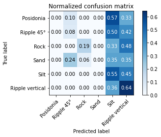

```python
plot_confusion_matrix(y_test, predict, label_names_unique, normalize=True, title=None, cmap=plt.cm.Blues)
```

Métriques du model:

```python
get_metrics(y_test, predict)
```

```
Accuracy: 0.2269
Precision: 0.253
Recall: 0.2269
F1 Score: 0.17
```

## Reseau de Neuronnes

```python
# Sigmoid Gradient
def sigmoidGradient(z):
    return sigmoid(z)*(1-sigmoid(z))

# Random Initialization
def randInitializeWeights(L_in, L_out):
    epsilon_init = 0.12
    W =np.random.rand(L_out, 1+L_in) * 2 * epsilon_init -epsilon_init
    return W

# Cost and Gradient Function
def nnCostFunction(nn_params, input_layer_size, hidden_layer_size, num_labels, X, y, Lambda):
    # Reshape nn_params back into the parameters theta1 and theta2, the weight matrices
    # for our 2 layer neural network
    # Obtain theta1 and theta2 back from nn_params
    theta1 = nn_params[0:(hidden_layer_size*(input_layer_size+1))].reshape((input_layer_size+1),hidden_layer_size).T
    theta2 = nn_params[(hidden_layer_size*(input_layer_size+1)):].reshape((hidden_layer_size+1),num_labels).T

    # Setup some useful variables
    m, _ = X.shape
    theta1_grad = np.zeros(theta1.shape)
    theta2_grad = np.zeros(theta2.shape)

    y_matrix = (np.arange(1, y.max()+1) == y.flatten()[:,None]).astype(int).T

    # Compute Cost
    # =========================================================================
    ones = np.ones((m, 1))
    a1 = np.hstack((ones, X))
    a2 = sigmoid(a1 @ theta1.T)
    a2 = np.hstack((ones, a2))
    a3 = sigmoid(a2 @ theta2.T)
    h = a3
    y_d = pd.get_dummies(y.flatten())
    inner = np.array(y_d)*np.log(h) + (1 - np.array(y_d)*np.log(1 - h))
    J = -np.sum(inner) / m
    # Cost regularisation
    sum1 = np.sum(np.sum(np.square(theta1[:, 1:]), axis=1))
    sum2 = np.sum(np.sum(np.square(theta2[:, 1:]), axis=1))
    reg = (sum1 + sum2) * Lambda / (2 * m)
    J = J + reg
    # =========================================================================

    # Gradients
    # =========================================================================
    m = len(y)
    for i in range(X.shape[0]):
        a1 = np.hstack((1, X[i]))
        z2 = a1 @ theta1.T
        a2 = np.hstack((1, sigmoid(z2)))
        z3 = a2 @ theta2.T
        a3 = sigmoid(z3)

        d3 = a3 - y_d.iloc[i,:][np.newaxis,:]
        z2 = np.hstack((1, z2))
        d2 = np.multiply(theta2.T @ d3.T, sigmoidGradient(z2).T[:, np.newaxis])
        theta1_grad = theta1_grad + d2[1:, :] @ a1[np.newaxis, :]
        theta2_grad = theta2_grad + d3.T @ a2[np.newaxis, :]
    theta1_grad /= m
    theta2_grad /= m
    theta1_grad[:, 1:] = theta1_grad[:, 1:] + theta1[:, 1:] * Lambda / m
    theta2_grad[:, 1:] = theta2_grad[:, 1:] + theta2[:, 1:] * Lambda / m
    grad = np.hstack((theta1_grad.ravel(), theta2_grad.ravel()))
    # =========================================================================
    return J, grad

# training
def nnTrain(X_train, y_train, in_size, hidden_size, num_labes, Lambda=1, max_iter=100):
    #Init
    initial_theta1 = randInitializeWeights(in_size, hidden_size)
    initial_theta2 = randInitializeWeights(hidden_size, num_labels)

    # Unroll
    initial_nn_params = np.hstack((initial_theta1.T.ravel(), initial_theta2.T.ravel()))

    # Train
    costFunc = lambda p: nnCostFunction(p, input_layer_size, hidden_layer_size, num_labels, X_train, y_train, Lambda)[0]
    gradFunc = lambda p: nnCostFunction(p, input_layer_size, hidden_layer_size, num_labels, X_train, y_train, Lambda)[1]

    result = fmin_cg(costFunc, fprime=gradFunc, x0=initial_nn_params, maxiter=max_iter, disp=True,full_output=True)

    nn_params = result[0]
    cost = result[1]

    # Obtain theta1 and theta2 back from nn_params
    theta1_t = nn_params[0:(hidden_size*(in_size+1))].reshape((in_size+1),hidden_size).T
    theta2_t = nn_params[(hidden_size*(in_size+1)):].reshape((hidden_size+1),num_labels).T
    return theta1_t, theta2_t

#setting up NN Layes Parameters
input_layer_size = features_count
hidden_layer_size = 20
```

Entrainement du réseau de neuronnes:

```python
Lambda=1.0
theta_1, theta_2 = nnTrain(X_train, y_train, input_layer_size, hidden_layer_size, num_labels, Lambda, 100)
```

```python
def displayData(X):
    """
    displays 2D data
    stored in X in a nice grid. It returns the figure handle h and the
    displayed array if requested.
    """

# Compute rows, cols
    m, n = X.shape
    example_width = round(np.sqrt(n)).astype(int)
    example_height = (n / example_width).astype(int)

# Compute number of items to display
    display_rows = np.floor(np.sqrt(m)).astype(int)
    display_cols = np.ceil(m / display_rows).astype(int)

# Between images padding
    pad = 1

# Setup blank display
    display_array = - np.ones((pad + display_rows * (example_height + pad), pad + display_cols * (example_width + pad)))

# Copy each example into a patch on the display array
    curr_ex = 0
    for j in np.arange(display_rows):
        for i in np.arange(display_cols):
            if curr_ex > m:
                break
            # Get the max value of the patch
            max_val = np.max(np.abs(X[curr_ex, : ]))
            rows = [pad + j * (example_height + pad) + x for x in np.arange(example_height+1)]
            cols = [pad + i * (example_width + pad)  + x for x in np.arange(example_width+1)]
            display_array[min(rows):max(rows), min(cols):max(cols)] = X[curr_ex, :].reshape(example_height, example_width) / max_val
            curr_ex = curr_ex + 1
        if curr_ex > m:
            break

# Display Image
    display_array = display_array.astype('float32')
    plt.imshow(display_array.T)
    plt.set_cmap('gray')
# Do not show axis
    plt.axis('off')
    plt.show()
```

Affichage des coefficiant de la couche caché

[figure not shown]

```python
displayData(theta_1[:, 1:])
```

```python
def predictNeuralNetwork(Theta1, Theta2, X):
    """
    Outputs the predicted label of X given the
    trained weights of a neural network (Theta1, Theta2)
    """
    # Useful values
    m, _ = X.shape
    num_labels, _ = Theta2.shape
    # =========================================================================
    z2 = Theta1@X.T
    a2 = sigmoid(z2).T
    a2 = np.concatenate((np.ones((m, 1)), a2), axis=1)
    z3 = Theta2@a2.T
    h_theta = sigmoid(z3).T
    p = np.argmax(h_theta, axis=1).reshape((m,1)) + np.ones((m,1))
    # =========================================================================
    return p.flatten().astype('int32')

m, _ = X_test.shape
Xn = np.column_stack((np.ones((m, 1)), X_test))

predictions = predictNeuralNetwork(theta_1, theta_2, Xn)

accuracy = np.mean(np.double(predictions == y_test.flatten())) * 100
print("Accuracy of Model regression : {:.3f} %".format(accuracy))
```

```
Accuracy of Model regression : 11.765 %
```

Evaluation du Model:

```
Normalized confusion matrix
[[0. 0. 0. 0. 1. 0.]
 [0. 0. 0. 0. 1. 0.]
 [0. 0. 0. 0. 1. 0.]
 [0. 0. 0. 0. 1. 0.]
 [0. 0. 0. 0. 1. 0.]
 [0. 0. 0. 0. 1. 0.]]
```

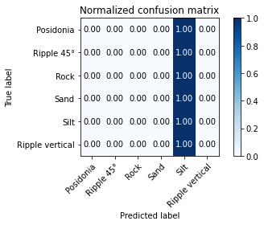

```python
plot_confusion_matrix(y_test.reshape(predictions.shape), predictions-1, label_names_unique, normalize=True, title=None, cmap=plt.cm.Blues)
```

Metriques du model:

```python
get_metrics(y_test, predictions)
```

```
Accuracy: 0.1176
Precision: 0.0138
Recall: 0.1176
F1 Score: 0.0248
```

## SKLearn: Regression Logisitique

```python
from sklearn.datasets import load_iris
from sklearn.linear_model import LogisticRegression
```

```python
logisticReg = LogisticRegression(random_state=0).fit(X_train, y_train)
print("Accuracy of logistic regression : {:.3f} %".format(logisticReg.score(X_test, y_test)*100))
```

```
Accuracy of logistic regression : 35.294 %
```

```
Normalized confusion matrix
[[0.14285714 0.         0.         0.         0.33333333 0.52380952]
 [0.20833333 0.08333333 0.         0.         0.41666667 0.29166667]
 [0.14285714 0.         0.23809524 0.         0.19047619 0.42857143]
 [0.23529412 0.         0.         0.         0.17647059 0.58823529]
 [0.         0.         0.         0.         0.81818182 0.18181818]
 [0.         0.         0.         0.         0.         1.        ]]
```

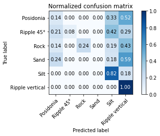

```python
pred = logisticReg.predict(X_test)
plot_confusion_matrix(y_test, pred, label_names_unique, normalize=True, title=None, cmap=plt.cm.Blues)
```

```python
get_metrics(y_test, pred)
```

```
Accuracy: 0.3529
Precision: 0.5226
Recall: 0.3529
F1 Score: 0.28
```

## SKLearn: Reseau de Neuronnes

```python
from sklearn.neural_network import MLPClassifier
```

```python
neuralNet = MLPClassifier(solver='lbfgs', alpha = 1e-5, hidden_layer_sizes=(20), random_state=1)
neuralNet.fit(X_train, y_train)
```

```
MLPClassifier(alpha=1e-05, hidden_layer_sizes=20, random_state=1,
              solver='lbfgs')
```

```python
print("Accuracy of logistic regression : {:.3f} %".format(neuralNet.score(X_test, y_test)*100))
```

```
Accuracy of logistic regression : 28.571 %
```

```
Normalized confusion matrix
[[0.04761905 0.         0.         0.         0.42857143 0.52380952]
 [0.16666667 0.20833333 0.         0.         0.25       0.375     ]
 [0.04761905 0.0952381  0.23809524 0.         0.28571429 0.33333333]
 [0.05882353 0.23529412 0.         0.         0.47058824 0.23529412]
 [0.         0.         0.         0.         0.5        0.5       ]
 [0.         0.         0.         0.         0.14285714 0.85714286]]
```

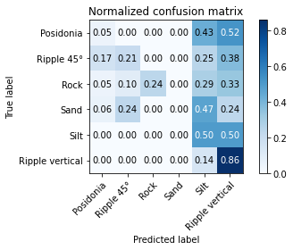

```python
pred = neuralNet.predict(X_test)
plot_confusion_matrix(y_test, pred, label_names_unique, normalize=True, title=None, cmap=plt.cm.Blues)
```

```python
get_metrics(y_test, pred)
```

```
Accuracy: 0.2857
Precision: 0.3679
Recall: 0.2857
F1 Score: 0.2432
```

## SKLearn: Support Vector Machines (SVM)

```python
from sklearn import svm
```

```python
suppVec = svm.SVC(C=10)
suppVec.fit(X_train, y_train)
```

```
SVC(C=10)
```

```
Accuracy of Model : 63.025 %

Model Metrics:
Accuracy: 0.6303
Precision: 0.6125
Recall: 0.6303
F1 Score: 0.5974


Normalized confusion matrix
[[0.66666667 0.         0.         0.         0.14285714 0.19047619]
 [0.16666667 0.25       0.16666667 0.20833333 0.20833333 0.        ]
 [0.14285714 0.14285714 0.33333333 0.33333333 0.04761905 0.        ]
 [0.         0.11764706 0.11764706 0.76470588 0.         0.        ]
 [0.04545455 0.         0.         0.         0.95454545 0.        ]
 [0.         0.         0.         0.         0.         1.        ]]
```

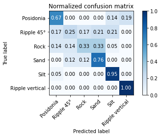

```python
print("Accuracy of Model : {:.3f} %".format(suppVec.score(X_test, y_test)*100))
pred = suppVec.predict(X_test)
print("\nModel Metrics:")
get_metrics(y_test, pred)
print("\n")
plot_confusion_matrix(y_test, pred, label_names_unique, normalize=True, title=None, cmap=plt.cm.Blues)
```

## SKLearn: Random Forest

```python
from sklearn.ensemble import RandomForestClassifier
```

```python
rngForest = RandomForestClassifier(max_depth=3, random_state=0)
rngForest.fit(X_train, y_train)
```

```
RandomForestClassifier(max_depth=3, random_state=0)
```

```
Accuracy of model : 52.101 %

Model Metrics:
Accuracy: 0.521
Precision: 0.5582
Recall: 0.521
F1 Score: 0.4879


Normalized confusion matrix
[[0.38095238 0.04761905 0.         0.         0.0952381  0.47619048]
 [0.125      0.16666667 0.08333333 0.04166667 0.33333333 0.25      ]
 [0.0952381  0.0952381  0.42857143 0.14285714 0.14285714 0.0952381 ]
 [0.05882353 0.11764706 0.05882353 0.35294118 0.         0.41176471]
 [0.04545455 0.         0.         0.         0.95454545 0.        ]
 [0.         0.         0.         0.         0.         1.        ]]
```

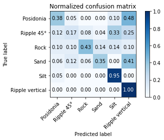

```python
print("Accuracy of model : {:.3f} %".format(rngForest.score(X_test, y_test)*100))
pred = rngForest.predict(X_test)
print("\nModel Metrics:")
get_metrics(y_test, pred)
print("\n")
plot_confusion_matrix(y_test, pred, label_names_unique, normalize=True, title=None, cmap=plt.cm.Blues)
```

**Question: Réalisez un diagramme fonctionnel décrivant le flux des données tout au long de l'approche supervisée. Ce diagramme devra faire apparaître au minimum: les trois ensembles d'images, les descripteurs, les différents algorithmes d'apprentissage, l'évaluation (mettre une image dans le répertoire courant et dans la cellule ci-dessous remplacer par le nom du fichier)**

[figure not shown]

# Partie 2: Approche supervisée sur descripteurs issus du scattering operator

## Chargement des descripteurs

**Question: Chargez les données du fichier matlab imdb_200x200_SmallSonarTex_db_6classes_scatValOnly.mat**

*Your Code below*

```python
from scipy.io import loadmat
import sys
IN_COLAB = 'google.colab' in sys.modules

if IN_COLAB:
    DATASET_PATH = '/content/drive/MyDrive/Colab Notebooks/dataset/'
    DATASET_FILE = '/content/drive/MyDrive/Colab Notebooks/dataset/imdb_200x200_SmallSonarTex_db_6classes_scatValOnly.mat'
    #os.chdir("/content/drive/MyDrive/Colab Notebooks")
    #from pythonTools import *
else:
    IN_COLAB = False
    DATASET_PATH = r'./dataset/'
    DATASET_FILE = r'./imdb_200x200_SmallSonarTex_db_6classes_scatValOnly.mat'
    from pythonTools import *

# Loading the csv file
DATASET = os.path.join(DATASET_PATH, DATASET_FILE)

# Loading the dataset
dataset_mat = loadmat(DATASET)
print(dataset_mat["featVal"].shape)
X = dataset_mat["featVal"]
print("X min: {:.3f} | X max: {:.3f}".format(np.amin(X),np.amax(X)))
```

```
(360, 217)
X min: 0.615 | X max: 2323.032
```

## Prétraitements

**Question: Y-a-t-il besoin de normaliser les descripteurs? Si oui, que faut-il conserver comme information et pourquoi?**

La normalisaion des descripteurs permet l'optimisation des traitements, le plus important etant de conserver les contrast des images si ce nes même les exacerber afin de facilité les decisions

```python
norm = preprocessing.MinMaxScaler().fit(X)
X_norm = norm.transform(X)
print("X_norm min: {:.3f} | X_norm max: {:.3f}".format(np.amin(X_norm),np.amax(X_norm)))
```

```
X_norm min: 0.000 | X_norm max: 1.000
```

## Séparation des données

```python
X_train, X_test, y_train, y_test = train_test_split(X_norm, y, test_size=0.33, random_state=42)
print("Training and testing sets:\n\tX_train: {}\n\ty_train: {}\n\tX_test:  {}\n\ty_test:  {}".format(X_train.shape, y_train.shape,X_test.shape,y_test.shape))

print("\nDatasets representativeness:")
ind, counts = np.unique(le.inverse_transform(y_train), return_counts=True)
train_classes =dict(zip(ind, counts))
print("\tTraining : {}".format(train_classes))

ind, counts = np.unique(le.inverse_transform(y_test), return_counts=True)
test_classes =dict(zip(ind, counts))
print("\tTesting  : {}".format(test_classes))

classes = {}
for key, item in train_classes.items():
    classes[key] = item + test_classes[key]

print("\nFull Dataset classes:\n\t{}".format(classes))
```

```
Training and testing sets:
	X_train: (241, 217)
	y_train: (241, 1)
	X_test:  (119, 217)
	y_test:  (119, 1)

Datasets representativeness:
	Training : {'Posidonia': 39, 'Ripple 45°': 36, 'Ripple vertical': 39, 'Rock': 43, 'Sand': 38, 'Silt': 46}
	Testing  : {'Posidonia': 21, 'Ripple 45°': 24, 'Ripple vertical': 21, 'Rock': 17, 'Sand': 22, 'Silt': 14}

Full Dataset classes:
	{'Posidonia': 60, 'Ripple 45°': 60, 'Ripple vertical': 60, 'Rock': 60, 'Sand': 60, 'Silt': 60}
```

## Apprentissage

recuperation des meilleurs Hyperparametres via **GridSearchCV**

```python
from sklearn.model_selection import GridSearchCV
```

### Neural Network

```
Les meilleur hyper-paramètres trouvés sont:
{'activation': 'tanh', 'alpha': 0.1, 'hidden_layer_sizes': 50, 'learning_rate': 'adaptive', 'solver': 'adam'}

Accuracy of model : 96.639 %

Model Metrics:
Accuracy: 0.9664
Precision: 0.9684
Recall: 0.9664
F1 Score: 0.9662


Normalized confusion matrix
[[1.         0.         0.         0.         0.         0.        ]
 [0.         0.875      0.         0.04166667 0.         0.08333333]
 [0.         0.         1.         0.         0.         0.        ]
 [0.         0.         0.         1.         0.         0.        ]
 [0.         0.         0.         0.         1.         0.        ]
 [0.         0.         0.07142857 0.         0.         0.92857143]]
```

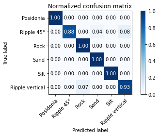

```python
mlp = MLPClassifier(max_iter=100)
parameter_space = {
    'hidden_layer_sizes': [15,50,100],
    'activation': ['tanh', 'relu'],
    'solver': ['sgd', 'adam'],
    'alpha': [0.0001, 0.01, 0.1, 0.5, 1],
    'learning_rate': ['constant','adaptive'],
}
clf = GridSearchCV(mlp, parameter_space, n_jobs=-1, cv=3)
clf.fit(X_train, y_train)
print('Les meilleur hyper-paramètres trouvés sont: \n{}'.format(clf.best_params_))
y_true, pred = y_test, clf.predict(X_test)
print("\nAccuracy of model : {:.3f} %".format(clf.score(X_test, y_test)*100))
print("\nModel Metrics:")
get_metrics(y_test, pred)
print("\n")
plot_confusion_matrix(y_test, pred, label_names_unique, normalize=True, title=None, cmap=plt.cm.Blues)
```

### Regression Logisitique

```
Les meilleur hyper-paramètres trouvés sont:
{'C': 100}

Accuracy of model : 99.160 %

Model Metrics:
Accuracy: 0.9916
Precision: 0.9921
Recall: 0.9916
F1 Score: 0.9916


Normalized confusion matrix
[[1.         0.         0.         0.         0.         0.        ]
 [0.         0.95833333 0.         0.04166667 0.         0.        ]
 [0.         0.         1.         0.         0.         0.        ]
 [0.         0.         0.         1.         0.         0.        ]
 [0.         0.         0.         0.         1.         0.        ]
 [0.         0.         0.         0.         0.         1.        ]]
```

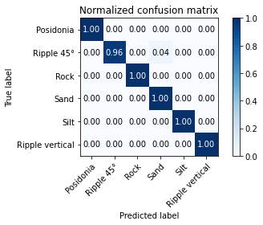

```python
logReg = LogisticRegression(random_state=0)
parameter_space = {
    'C': [1e-6, 1e-5, 1e-3, 1e-2, 0.1, 0.5, 1, 5, 10, 100, 1e4]
}
clf = GridSearchCV(logReg, parameter_space, n_jobs=-1, cv=3)
clf.fit(X_train, y_train)
print('Les meilleur hyper-paramètres trouvés sont: \n{}'.format(clf.best_params_))
y_true, pred = y_test, clf.predict(X_test)
print("\nAccuracy of model : {:.3f} %".format(clf.score(X_test, y_test)*100))
print("\nModel Metrics:")
get_metrics(y_test, pred)
print("\n")
plot_confusion_matrix(y_test, pred, label_names_unique, normalize=True, title=None, cmap=plt.cm.Blues)
```